# Coursework Report

*N* removed NAs: 2

*N* removed typo: 1

*N* removed <18: 26

*N* total clean: 121

| Group | *N* | *M*<sub>age</sub> | *M*<sub>rating</sub> |
| --- | --- | --- | --- |
| Control | 64 | 20.8 | 6.36 |
| Experim | 57 | 21.1 | 5.21 |

**Main analysis results**

*t*(119) = 8.93, *p* < .001

[interactive chart not shown]

[figure not shown]

[interactive chart not shown]

# Coursework Report

Analysing Data, Spring 2020

# Methods

## Participants

Table 1. Summary of mean Age by Condition

| condition | n | mean_age | sd_age | min_years | max_years |
| --- | --- | --- | --- | --- | --- |
| control | 64 | 20.8 | 2.19 | 18 | 27 |
| experimental | 57 | 21.1 | 2.44 | 18 | 27 |

## Design

The study’s conceptual hypothesis investigated whether color, particularly red, can change people’s perceived attractiveness of others. Thus, a man’s photo in red color background would be rated as more attractive by women, than a photo in a white color background. The dependent variable of the study was the attractiveness rated and the independent categorical variable was the color of the background participants were exposed to; red or white. Therefore, attractiveness would be the outcome which was dependent on the manipulation of color, the predictor. Participants were randomly allocated to the conditions of the study which were factors with two levels; the red (experimental) and white (control). Hence, the design of the study was a between-groups, as participants viewed and rated the man either in the red or white condition. There were 64 participants in the white condition and 57 in the red condition. The photo presented to participants was of a moderately attractive Caucasian male in black and white, who was placed in either a red or white frame.The male was the same in both conditions to avoid confounding variables influencing results. After the photos were presented to participants they had to answer three questions from which data was gathered likewise in the original study; (“How attractive do you think this person is?”, “How pleasant is this person to look at?” and “If I were to meet the person in this picture face to face, I would think he is attractive.”). All the questions were ratings of attractiveness and used Likert scales of 1 - 9, with 1 representing one being not attractive at all and 9 representing one being extremely attractive. The scores taken from the questions were averaged in order to get a composite index and compare the different conditions. In order to analyse and observe the significance of the results differences, the statistical independent measures t-test will be used. Hence, the operational hypothesis of the replication study was whether a different color background (/frame) in a male’s image could affect the mean rating of his attractiveness.

# Results

The replication study examined whether the attractiveness of an average attractive man in a picture, depending on the color background around him, would influence participants ratings of him. In order to do that, after the data were transferred in the r_studio computer program, they needed to go through some transformations. Therefore, as some values were not in their appropriate form, the years of the participants changed from a factor to a numeric value form. Additionally, written mistakes in the participants’ conditions changed, such as the wrong spelled ‘exprimental’ to ‘experimental’, so that all the values and scores could be considered and interpreted. After the values from the data were ready to be analyzed, the mean responses of each condition group to the three posed questions about the man’s attractiveness were calculated. Thus, participants’ total score on each of the Likert scales questions were analysed by condition as seen in Table 2.

*Table 2. Mean Scores in each question by Condition*

| Condition | Number of Participants | Mean Score Question 1 | Mean Score Question 2 | Mean Score Question 3 |
| --- | --- | --- | --- | --- |
| control | 64 | 6.42 | 6.33 | 6.33 |
| experimental | 57 | 5.21 | 5.16 | 5.26 |

Composite scores were then created from the mean score of the three questions for every participant, to assess the differences between the two conditions. Results depicted that the mean response in questions of participants in the control condition were higher than from the one’s in the experimental condition, as shown in Table 3.

*Table 3. Descriptives of Results by Condition*

| Condition | Mean Score | Standard Deviation | Minimum Score | Maximum Score | Range |
| --- | --- | --- | --- | --- | --- |
| control | 6.36 | 0.71 | 4.67 | 8.00 | 3.33 |
| experimental | 5.21 | 0.71 | 3.00 | 6.67 | 3.67 |

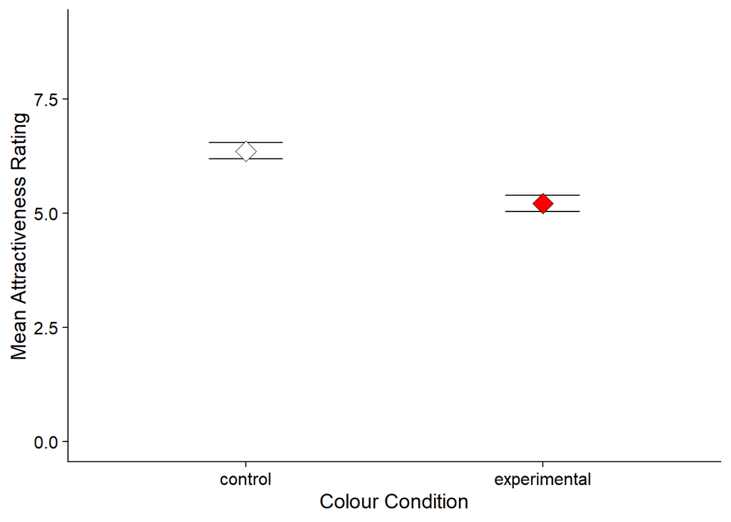

```r
attractiveness.plot
```

# Discussion

The replication study used the white color in the control condition opposing to red as it’s perceived to be an achromatic color (Elliot & Niesta, 2008). Different studies have used this method in order to test the hypothesis concerning red color and attractiveness relationship like Schwarz and Singer (2013). However, this way studies cannot see whether red would have similar effect if contrasted with other colors such as green or blue (Pazda et al., 2012) to test the general idea that color influences attractiveness. In real life settings you can have a first impression of a male in backgrounds (i.e. walls) or in clothing that are not always white. The present replication study lacks into considering real-life situations and further research could involve testing with other vibrant colors likewise red to test whether then it could influence attractiveness.

Additionally, the research aimed to avoid confounding variables by using the same male face as the target subject in the photos rated. However, by using only one photo and particularly of a Caucasian male, not only racial and cultural biases are presented but also the findings cannot be generalised to a wider population. Therefore, further research could also consider using both males and females from multiple cultural backgrounds (Young, 2015) in order to review sexual preferences influences [heterosexuals-homosexuals (Elliot & Niesta, 2008)] and further examine the effect of color. Furthermore the design of the study being a between-subjects allowed for randomization of the two conditions so that order effects and familiarity of participants with the target photo would not act as confounding variables to the results. However, this way the study does not have control of whether a participant’s preference over the color red or white could affect their opinion, something that could be avoided with a within measures design(Roberts et al., 2010). In the future, studies could involve a mixed design so that both of the advantages of each design could work in favor of the results. Lastly another limitation of the study is the fact that it was conducted under laboratory conditions which provide an artificial environment. Thus the ecological validity of the study is low since it cannot reflect how people would respond in their natural environment. Nevertheless, only a laboratory (or true) experiment can provide a cause and effect relationship, therefore it is easier to support that our findings are valid. Another factor influencing is the small sample generated to conclude into findings, since it is proven that larger samples allow for better generalisations to wider population groups.

In conclusion, this replication study does not accept the original hypothesis and rejects Elliot et al. 2010 findings. However, this does not mean the results and conclusions depicted are not important since there are supported by other research as well ( Peperkoorn, Roberts et al., 2016). The study’s limitations do not allow to question the points made but encourage further improvements. Hence, they invite further research to be conducted in order to have a clear image of the actual; effect that color, especially red, can have in perceived attractiveness.

# References

Aslam, M. M. (2006). Are You Selling the Right Colour? A Cross-cultural Review of Colour as a Marketing Cue. Journal of Marketing Communications, 12(1), 15–30. https://doi.org/10.1080/13527260500247827

Elliot, A. J., & Maier, M. A. (2013). The red-attractiveness effect, applying the Ioannidis and Trikalinos (2007b) test, and the broader scientific context: A reply to Francis (2013). Journal of Experimental Psychology: General, 142(1), 297–300. https://doi.org/10.1037/a0029592

Elliot, A. J., & Niesta, D. (2008). Romantic red: Red enhances men’s attraction to women. Journal of Personality and Social Psychology, 95(5), 1150–1164. https://doi.org/10.1037/0022-3514.95.5.1150

Elliot, A. J., Niesta Kayser, D., Greitemeyer, T., Lichtenfeld, S., Gramzow, R. H., Maier, M. A., & Liu, H. (2010). Red, rank, and romance in women viewing men. J ournal of Experimental Psychology: General , 139 (3), 399–417. https://doi.org/10.1037/a0019689

Hesslinger, V.M., Goldbach, L. & Carbon, C. (2015). Men in red: A reexamination of the red-attractiveness effect. Psychonomic Bulletin & Review 22, 1142–1148 . https://doi.org/10.3758/s13423-015-0866-8

Pazda, A. D., Elliot, A. J., & Greitemeyer, T. (2012). Sexy red: Perceived sexual receptivity mediates the red-attraction relation in men viewing woman. Journal of Experimental Social Psychology, 48(3), 787–790. https://doi.org/10.1016/j.jesp.2011.12.009

S. C., & Pollet, T. V. (2016). Revisiting the red effect on attractiveness and sexual receptivity: No effect of the color red on human mate preferences. Evolutionary Psychology, 14(4), Article 1474704916673841. https://doi.org/10.1177/1474704916673841

Roberts, S. C., Owen, R. C., Havlicek, J. (2010). Distinguishing between perceiver and wearer effects in clothing color-associated attributions. Evolutionary Psychology, 8, 350–364.

Schwarz, S., & Singer, M. (2013). Romantic red revisited: Red enhances men’s attraction to young, but not menopausal women. Journal of Experimental Social Psychology, 49(1), 161–164. https://doi.org/10.1016/j.jesp.2012.08.004

Waitt, C., Little, A. C., Wolfensohn, S., Honess, P., Brown, A. P., Buchanan-Smith, H. M., & Perrett, D. I. (2003). Evidence from rhesus macaques suggests that male coloration plays a role in female primate mate choice. Proceedings of the Royal Society B: Biological Sciences, 270(SUPPL. 2), S144-S146. https://doi.org/10.1098/rsbl.2003.0065

Young, S. G. (2015). The effect of red on male perceptions of female attractiveness: Moderation by baseline attractiveness of female faces. European Journal of Social Psychology, 45(2), 146–151. https://doi.org/10.1002/ejsp.2098